# Diversity calculation

Masatoshi Katabuchi

October 31, 2019

# 1 Prerequisites

Did you install `picante` and `FD`?

```r
install.packages("picante")
install.packages("FD")
```

It’s better if you have those packages too.

```r
install.packages("dplyr")
install.packages("DT")
install.packages("ggplot2")
install.packages("rmarkdown")
```

```r
library(picante)
library(FD)
library(dplyr)
library(ggplot2)
library(rmarkdown)
```

# 2 Data

## 2.1 Community

```r
samp <- read_csv("./data/samp.csv")
DT::datatable(samp)
```

|  | Site | Illicium_macranthum | Manglietia_insignis | Michelia_floribunda | Beilschmiedia_robusta | Neolitsea_chuii | Lindera_thomsonii | Actinodaphne_forrestii | Machilus_yunnanensis |
| --- | --- | --- | --- | --- | --- | --- | --- | --- | --- |
| 1 | Site1 | 1 | 0 | 0 | 0 | 0 | 0 | 0 | 0 |
| 2 | Site2 | 1 | 2 | 2 | 2 | 0 | 0 | 0 | 0 |
| 3 | Site3 | 1 | 0 | 0 | 0 | 0 | 2 | 2 | 2 |
| 4 | Site4 | 1 | 1 | 0 | 0 | 0 | 2 | 2 | 0 |
| 5 | Site5 | 1 | 0 | 0 | 0 | 1 | 1 | 0 | 0 |

```r
samp_mat <- as.matrix(samp[, -1])
rownames(samp_mat) <- samp$Site

samp_mat
```

```
##       Illicium_macranthum Manglietia_insignis Michelia_floribunda
## Site1                   1                   0                   0
## Site2                   1                   2                   2
## Site3                   1                   0                   0
## Site4                   1                   1                   0
## Site5                   1                   0                   0
##       Beilschmiedia_robusta Neolitsea_chuii Lindera_thomsonii
## Site1                     0               0                 0
## Site2                     2               0                 0
## Site3                     0               0                 2
## Site4                     0               0                 2
## Site5                     0               1                 1
##       Actinodaphne_forrestii Machilus_yunnanensis
## Site1                      0                    0
## Site2                      0                    0
## Site3                      2                    2
## Site4                      2                    0
## Site5                      0                    0
```

## 2.2 Phylogeny

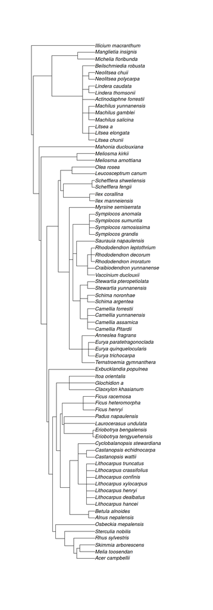

```r
phylo <- read.tree("./data/phylo.tre")
plot(phylo)
```

## 2.3 Traits

```r
trait <- read_csv("./data/trait.csv")
# trait <- read.csv("./data/trait.csv") is fine too.

DT::datatable(trait)
```

|  | Species | SLA | RootTissueDens | LeafArea | LeafThickness | LeafTissueDens | RootDiam |
| --- | --- | --- | --- | --- | --- | --- | --- |
| 1 | Illicium_macranthum | 12321 | 0.92 | 9.27539 | 0.416333333 | 0.018085428 | 0.31236 |
| 2 | Manglietia_insignis | 567 | 0.87 | 0.274745 | 0.2535 | 0.017706402 | 0.114871429 |
| 3 | Michelia_floribunda | 753 | 0.5 | 1.73199 | 0.281 | 0.020920233 | 0.27495 |
| 4 | Beilschmiedia_robusta | 56 | 0.250416667 | 0.3172 | 0.246666667 | 0.02104834 | 0.34955 |
| 5 | Neolitsea_chuii | 43 | 0.324830317 | 4.916716667 | 0.406666667 | 0.010532563 | 0.51545 |
| 6 | Neolitsea_polycarpa | 56 | 0.3 | 1.962466667 | 0.403333333 | 0.01153886 | 0.2433 |
| 7 | Lindera_caudata | 89 | 0.5 | 1.070105 | 0.424166667 | 0.015304661 | 0.31 |
| 8 | Lindera_thomsonii | 65 | 0.1 | 1.962466667 | 0.403333333 | 0.01153886 | 0.2433 |
| 9 | Actinodaphne_forrestii | 89 | 0.74 | 2.445361111 | 0.914722222 | 0.008137136 | 0.310783333 |
| 10 | Machilus_yunnanensis | 75 | 0.3 | 14.06485556 | 0.29 | 0.022841232 | 0.376066667 |

[output cut: 67 more lines]

## 2.4 Check the histograms of trait values first

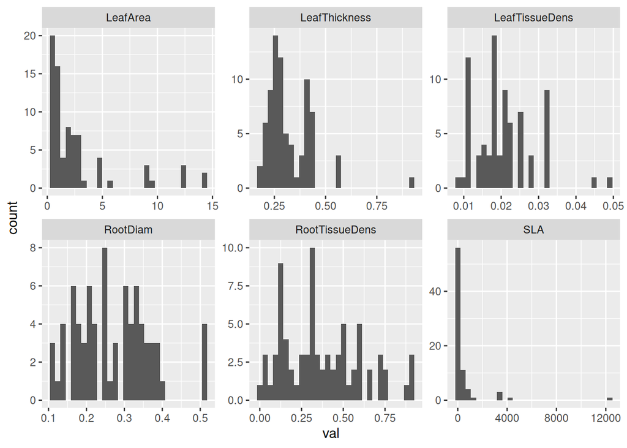

```r
trait_long <- trait %>%
  gather(trait, val, 2:7)

ggplot(trait_long, aes(x = val)) +
  geom_histogram(position = "identity") +
  facet_wrap(~ trait, scale = "free")
```

Probably we can do log-transformation for leaf area, leaf thickness, leaf tissue density, and SLA

```r
trait2 <- trait %>%
  mutate(logLA = log(LeafArea),
         logLT = log(LeafThickness),
         logLD = log(LeafTissueDens),
         logSLA = log(SLA),
         RDia = RootDiam,
         RD = RootTissueDens) %>%
  dplyr::select(Species, logLA, logLT, logLD, logSLA, RDia, RD)

DT::datatable(trait2)
```

|  | Species | logLA | logLT | logLD | logSLA | RDia | RD |
| --- | --- | --- | --- | --- | --- | --- | --- |
| 1 | Illicium_macranthum | 2.227364656127 | -0.87626905832531 | -4.01264874783655 | 9.41906040262467 | 0.31236 | 0.92 |
| 2 | Manglietia_insignis | -1.29191188422615 | -1.3723914559509 | -4.03382900988294 | 6.34035930372775 | 0.114871429 | 0.87 |
| 3 | Michelia_floribunda | 0.54927103645152 | -1.26940060964839 | -3.86703850218013 | 6.62406522779989 | 0.27495 | 0.5 |
| 4 | Beilschmiedia_robusta | -1.14822278922144 | -1.39971738010068 | -3.86093358182083 | 4.02535169073515 | 0.34955 | 0.250416667 |
| 5 | Neolitsea_chuii | 1.59264096362533 | -0.899761429103272 | -4.55328358264311 | 3.76120011569356 | 0.51545 | 0.324830317 |
| 6 | Neolitsea_polycarpa | 0.674202185562027 | -0.907991929885906 | -4.46203480961035 | 4.02535169073515 | 0.2433 | 0.3 |
| 7 | Lindera_caudata | 0.0677567745004203 | -0.857628818439714 | -4.17959785645437 | 4.48863636973214 | 0.31 | 0.5 |
| 8 | Lindera_thomsonii | 0.674202185562027 | -0.907991929885906 | -4.46203480961035 | 4.17438726989564 | 0.2433 | 0.1 |
| 9 | Actinodaphne_forrestii | 0.894192805681732 | -0.0891348423107767 | -4.81131700363071 | 4.48863636973214 | 0.310783333 | 0.74 |
| 10 | Machilus_yunnanensis | 2.64367917242588 | -1.23787435600162 | -3.77918795519372 | 4.31748811353631 | 0.376066667 | 0.3 |

[output cut: 67 more lines]

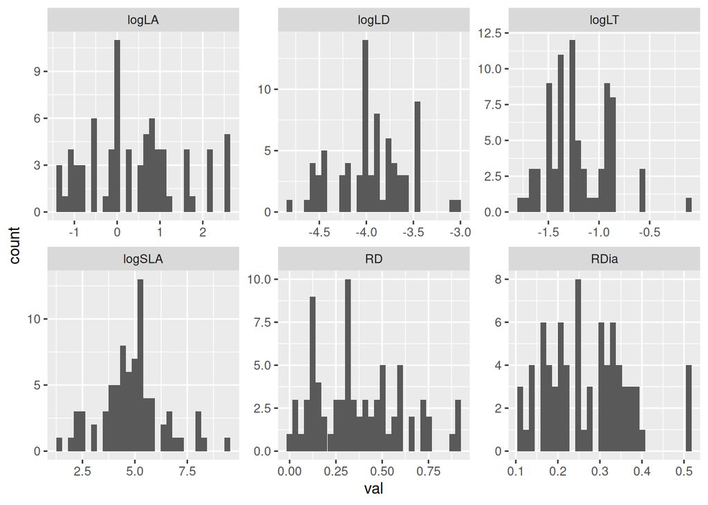

```r
trait2 %>%
  gather(trait, val, 2:7) %>%
  ggplot(., aes(x = val)) +
  geom_histogram(position = "identity") +
  facet_wrap(~ trait, scale = "free")
```

# 3 Fisrt-order metrics (without phylogeny or traits)

## 3.1 Species richness, Beta diversity metrics

Skip

## 3.2 Nonmetric Multidimensional Scaling (NMDS)

```r
res_mds <- metaMDS(samp_mat)
```

```
## *** No convergence -- monoMDS stopping criteria:
##     13: stress < smin
##      5: stress ratio > sratmax
##      2: scale factor of the gradient < sfgrmin
```

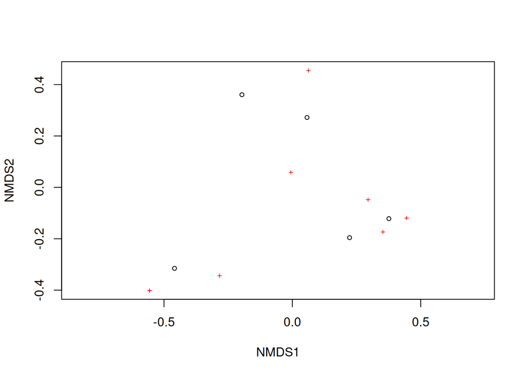

```r
plot(res_mds)
```

We can use the function ordiplot and orditorp to add text to the plot in place of points to make some more sence.

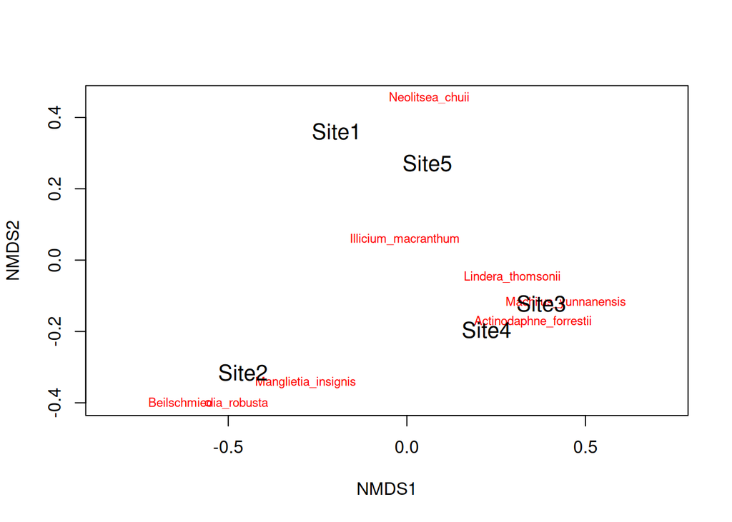

```r
ordiplot(res_mds, type = "n")
orditorp(res_mds,display="species",col="red",air=0.01)
orditorp(res_mds,display="sites",cex=1.25,air=0.01)
```

# 4 Phylogenetic metrics

## 4.1 Branch length based metric

### 4.1.1 PD

```r
res_pd <- pd(samp_mat, phylo)

res_pd
```

```
##             PD SR
## Site1 297.9167  1
## Site2 878.9444  4
## Site3 711.3889  4
## Site4 855.8333  4
## Site5 653.6111  3
```

You can always see the help.

```r
?pd
```

## 4.2 Distance based metric

`cophenetic()` creates distance matrices based on phylogenetic trees. Let’s see the first 5 species.

```r
cophenetic(phylo)[1:5, 1:5]
```

```
##                     Acer_campbellii Melia_toosendan Skimmia_arborescens
## Acer_campbellii              0.0000        170.2381            170.2381
## Melia_toosendan            170.2381          0.0000            141.8651
## Skimmia_arborescens        170.2381        141.8651              0.0000
## Rhus_sylvestris            198.6111        198.6111            198.6111
## Sterculia_nobilis          283.7302        283.7302            283.7302
##                     Rhus_sylvestris Sterculia_nobilis
## Acer_campbellii            198.6111          283.7302
## Melia_toosendan            198.6111          283.7302
## Skimmia_arborescens        198.6111          283.7302
## Rhus_sylvestris              0.0000          283.7302
## Sterculia_nobilis          283.7302            0.0000
```

### 4.2.1 MPD

$MPD = \frac{1}{n} \Sigma^n_i \Sigma^n_j \delta_{i,j} \; i \neq j$, where $\delta_{i, j}$ is the pairwised distance between species *i* and *j*

```r
res_mpd <- mpd(samp_mat, cophenetic(phylo))

res_mpd
```

```
## [1]       NA 459.6944 355.6944 451.9907 435.7407
```

The above vector shows MPD for each site.

### 4.2.2 MNTD

$MNTD = \frac{1}{n} \Sigma^n_i min \delta_{i,j} \; i \neq j$, where $min \delta_{i, j}$ is the minimum distance between species *i* and all other species in the community.

```r
res_mntd <- mntd(samp_mat, cophenetic(phylo))

res_mntd
```

```
## [1]       NA 330.9583 235.6250 307.8472 275.6481
```

# 5 Functional metrics

## 5.1 Distance based metrics

### 5.1.1 Prepare a trait distance matrix

We have a `data.fame` of traits. First we need to prepare a trait matrix, then a distance matrix based on trait values.

```r
trait_mat0 <- as.matrix(trait2[, -1])
rownames(trait_mat0) <- trait2$Species
```

Let’s see a subset of the trait matrix

```r
trait_mat0[1:5, 1:5]
```

```
##                           logLA      logLT     logLD   logSLA      RDia
## Illicium_macranthum    2.227365 -0.8762691 -4.012649 9.419060 0.3123600
## Manglietia_insignis   -1.291912 -1.3723915 -4.033829 6.340359 0.1148714
## Michelia_floribunda    0.549271 -1.2694006 -3.867039 6.624065 0.2749500
## Beilschmiedia_robusta -1.148223 -1.3997174 -3.860934 4.025352 0.3495500
## Neolitsea_chuii        1.592641 -0.8997614 -4.553284 3.761200 0.5154500
```

Then, we will make trait distance matrix based on the Euclidean distance. There are other distance measures, for example [Gower’s Distance](https://www.rdocumentation.org/packages/gower/versions/0.2.1/topics/gower_dist), but we focus on the Euclidean distance today.

Before calulating distance, we need to make sure unit change in ditances have same for different traits. We will scale trait values so that then have mean = 0 and SD = 1. (e.g., $(X_i - \mu) / \sigma$)

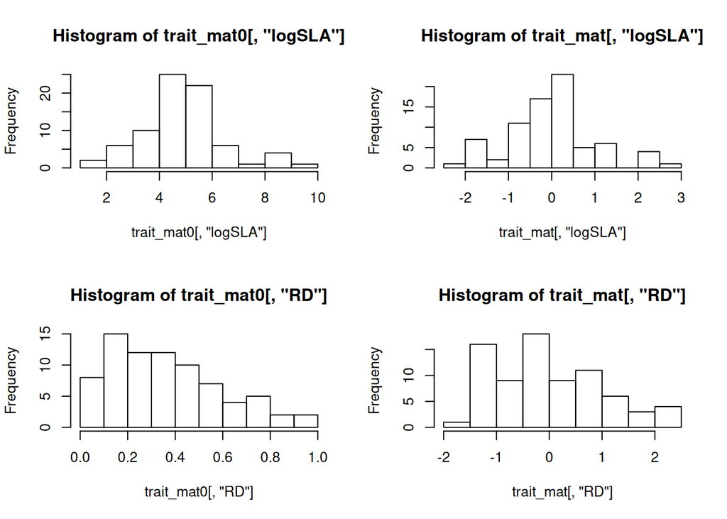

```r
trait_mat <- scale(trait_mat0)

par(mfrow = c(2, 2))
hist(trait_mat0[, "logSLA"])
hist(trait_mat[, "logSLA"])
hist(trait_mat0[, "RD"])
hist(trait_mat[, "RD"])
```

```r
par(mfrow = c(1, 1))
```

Now we can make a trait distance matirx.

```r
trait_dm <- as.matrix(dist(trait_mat))
```

Let’s see the first 5 species.

```r
trait_dm[1:5, 1:5]
```

```
##                       Illicium_macranthum Manglietia_insignis
## Illicium_macranthum              0.000000            4.632281
## Manglietia_insignis              4.632281            0.000000
## Michelia_floribunda              3.311259            2.896472
## Beilschmiedia_robusta            5.814290            3.895254
## Neolitsea_chuii                  5.190239            6.016073
##                       Michelia_floribunda Beilschmiedia_robusta
## Illicium_macranthum              3.311259              5.814290
## Manglietia_insignis              2.896472              3.895254
## Michelia_floribunda              0.000000              2.700164
## Beilschmiedia_robusta            2.700164              0.000000
## Neolitsea_chuii                  3.973360              3.942915
##                       Neolitsea_chuii
## Illicium_macranthum          5.190239
## Manglietia_insignis          6.016073
## Michelia_floribunda          3.973360
## Beilschmiedia_robusta        3.942915
## Neolitsea_chuii              0.000000
```

### 5.1.2 MPD

```r
mpd(samp_mat, trait_dm)
```

```
## [1]       NA 3.874953 4.546502 4.848792 4.518123
```

```r
ses.mpd(samp_mat, trait_dm)
```

```
##       ntaxa  mpd.obs mpd.rand.mean mpd.rand.sd mpd.obs.rank mpd.obs.z
## Site1     1       NA           NaN          NA           NA        NA
## Site2     4 3.874953      3.271413   0.6567091          820 0.9190377
## Site3     4 4.546502      3.254891   0.6421544          966 2.0113723
## Site4     4 4.848792      3.263489   0.6538256          992 2.4246572
## Site5     3 4.518123      3.268605   0.8015377          929 1.5589002
##       mpd.obs.p runs
## Site1        NA  999
## Site2     0.820  999
## Site3     0.966  999
## Site4     0.992  999
## Site5     0.929  999
```

### 5.1.3 MNTD

```r
mntd(samp_mat, trait_dm)
```

```
## [1]       NA 2.902015 3.748249 4.318827 3.768704
```

## 5.2 Branch length based metric

### 5.2.1 FD

We will make a functional dendrogram using clustring methods. We use UPGMA in this example.

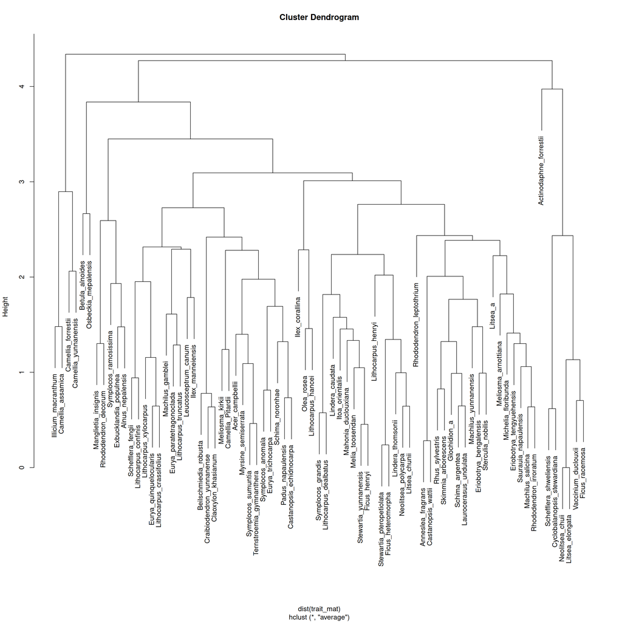

```r
t_clust <- hclust(dist(trait_mat), method = "average")

plot(t_clust)
```

### 5.2.2 More functional diversity metrics

```r
res_fd <- dbFD(trait_mat[colnames(samp_mat), ], samp_mat)

res_fd
```